# Credit Card Attrition Prediction

## Import Required Libraries

```python
import pandas as pd
from IPython.display import display
import numpy as np
import matplotlib.pyplot as plt
import seaborn as sns
from tabulate import tabulate
from sklearn.preprocessing import LabelEncoder, OneHotEncoder, StandardScaler, RobustScaler
from imblearn.over_sampling import SMOTE
from imblearn.under_sampling import RandomUnderSampler
from sklearn.impute import SimpleImputer
from sklearn.model_selection import train_test_split, GridSearchCV, RandomizedSearchCV, StratifiedKFold, cross_val_score
from sklearn.metrics import accuracy_score, confusion_matrix, classification_report, roc_auc_score, roc_curve, cohen_kappa_score, f1_score, precision_score, recall_score, precision_recall_curve, auc
from sklearn.linear_model import LogisticRegression
from sklearn.tree import DecisionTreeClassifier
from sklearn.ensemble import RandomForestClassifier
import lightgbm as lgb
import optuna
import warnings
warnings.filterwarnings('ignore')
```

## Import the Data

```python
# Mount google drive
from google.colab import drive
drive.mount('/content/drive')
```

```python
df = pd.read_csv('/content/drive/MyDrive/Credit Card Attrition Prediction/BankChurners.csv')
# Adjust Pandas display options to show all columns
pd.set_option('display.max_columns', None)  # None for unlimited columns
pd.set_option('display.max_rows', None)  # None for unlimited rows
df.head()
```

|  | CLIENTNUM | Attrition_Flag | Customer_Age | Gender | Dependent_count | Education_Level | Marital_Status | Income_Category | Card_Category | Months_on_book | Total_Relationship_Count | Months_Inactive_12_mon | Contacts_Count_12_mon | Credit_Limit | Total_Revolving_Bal | Avg_Open_To_Buy | Total_Amt_Chng_Q4_Q1 | Total_Trans_Amt | Total_Trans_Ct | Total_Ct_Chng_Q4_Q1 | Avg_Utilization_Ratio | Naive_Bayes_Classifier_Attrition_Flag_Card_Category_Contacts_Count_12_mon_Dependent_count_Education_Level_Months_Inactive_12_mon_1 | Naive_Bayes_Classifier_Attrition_Flag_Card_Category_Contacts_Count_12_mon_Dependent_count_Education_Level_Months_Inactive_12_mon_2 |
| --- | --- | --- | --- | --- | --- | --- | --- | --- | --- | --- | --- | --- | --- | --- | --- | --- | --- | --- | --- | --- | --- | --- | --- |
| 0 | 768805383 | Existing Customer | 45 | M | 3 | High School | Married | $60K - $80K | Blue | 39 | 5 | 1 | 3 | 12691.0 | 777 | 11914.0 | 1.335 | 1144 | 42 | 1.625 | 0.061 | 0.000093 | 0.99991 |
| 1 | 818770008 | Existing Customer | 49 | F | 5 | Graduate | Single | Less than $40K | Blue | 44 | 6 | 1 | 2 | 8256.0 | 864 | 7392.0 | 1.541 | 1291 | 33 | 3.714 | 0.105 | 0.000057 | 0.99994 |
| 2 | 713982108 | Existing Customer | 51 | M | 3 | Graduate | Married | $80K - $120K | Blue | 36 | 4 | 1 | 0 | 3418.0 | 0 | 3418.0 | 2.594 | 1887 | 20 | 2.333 | 0.000 | 0.000021 | 0.99998 |
| 3 | 769911858 | Existing Customer | 40 | F | 4 | High School | Unknown | Less than $40K | Blue | 34 | 3 | 4 | 1 | 3313.0 | 2517 | 796.0 | 1.405 | 1171 | 20 | 2.333 | 0.760 | 0.000134 | 0.99987 |
| 4 | 709106358 | Existing Customer | 40 | M | 3 | Uneducated | Married | $60K - $80K | Blue | 21 | 5 | 1 | 0 | 4716.0 | 0 | 4716.0 | 2.175 | 816 | 28 | 2.500 | 0.000 | 0.000022 | 0.99998 |

```python
# Create a copy
df1 = df.copy(deep=True)
```

## Data Exploration

```python
df1.info()
```

```
<class 'pandas.core.frame.DataFrame'>
RangeIndex: 10127 entries, 0 to 10126
Data columns (total 23 columns):
 #   Column                                                                                                                              Non-Null Count  Dtype
---  ------                                                                                                                              --------------  -----
 0   CLIENTNUM                                                                                                                           10127 non-null  int64
 1   Attrition_Flag                                                                                                                      10127 non-null  object
 2   Customer_Age                                                                                                                        10127 non-null  int64
 3   Gender                                                                                                                              10127 non-null  object
 4   Dependent_count                                                                                                                     10127 non-null  int64
 5   Education_Level                                                                                                                     10127 non-null  object
 6   Marital_Status                                                                                                                      10127 non-null  object
 7   Income_Category                                                                                                                     10127 non-null  object
 8   Card_Category                                                                                                                       10127 non-null  object
 9   Months_on_book                                                                                                                      10127 non-null  int64
 10  Total_Relationship_Count                                                                                                            10127 non-null  int64
 11  Months_Inactive_12_mon                                                                                                              10127 non-null  int64
 12  Contacts_Count_12_mon                                                                                                               10127 non-null  int64
 13  Credit_Limit                                                                                                                        10127 non-null  float64
 14  Total_Revolving_Bal                                                                                                                 10127 non-null  int64
 15  Avg_Open_To_Buy                                                                                                                     10127 non-null  float64
 16  Total_Amt_Chng_Q4_Q1                                                                                                                10127 non-null  float64
 17  Total_Trans_Amt                                                                                                                     10127 non-null  int64
 18  Total_Trans_Ct                                                                                                                      10127 non-null  int64
 19  Total_Ct_Chng_Q4_Q1                                                                                                                 10127 non-null  float64
 20  Avg_Utilization_Ratio                                                                                                               10127 non-null  float64
 21  Naive_Bayes_Classifier_Attrition_Flag_Card_Category_Contacts_Count_12_mon_Dependent_count_Education_Level_Months_Inactive_12_mon_1  10127 non-null  float64
 22  Naive_Bayes_Classifier_Attrition_Flag_Card_Category_Contacts_Count_12_mon_Dependent_count_Education_Level_Months_Inactive_12_mon_2  10127 non-null  float64
dtypes: float64(7), int64(10), object(6)
memory usage: 1.8+ MB
```

```python
# Removing the first and last columns from the dataset
df1 = df1.drop(['CLIENTNUM', 'Naive_Bayes_Classifier_Attrition_Flag_Card_Category_Contacts_Count_12_mon_Dependent_count_Education_Level_Months_Inactive_12_mon_1','Naive_Bayes_Classifier_Attrition_Flag_Card_Category_Contacts_Count_12_mon_Dependent_count_Education_Level_Months_Inactive_12_mon_2'], axis=1)
```

```python
# checking the shape of the data set
print("Total number of rows in the data set = {}".format(df.shape[0]))
print("Total number of columns in the data set = {}".format(df.shape[1]))
```

```
Total number of rows in the data set = 10127
Total number of columns in the data set = 23
```

```python
# checking the percentage of null values in each feature
(df1.isnull().sum()/df1.shape[0])*100
```

|  | 0 |
| --- | --- |
| Attrition_Flag | 0.0 |
| Customer_Age | 0.0 |
| Gender | 0.0 |
| Dependent_count | 0.0 |
| Education_Level | 0.0 |
| Marital_Status | 0.0 |
| Income_Category | 0.0 |
| Card_Category | 0.0 |
| Months_on_book | 0.0 |
| Total_Relationship_Count | 0.0 |
| Months_Inactive_12_mon | 0.0 |
| Contacts_Count_12_mon | 0.0 |
| Credit_Limit | 0.0 |
| Total_Revolving_Bal | 0.0 |
| Avg_Open_To_Buy | 0.0 |
| Total_Amt_Chng_Q4_Q1 | 0.0 |
| Total_Trans_Amt | 0.0 |
| Total_Trans_Ct | 0.0 |
| Total_Ct_Chng_Q4_Q1 | 0.0 |
| Avg_Utilization_Ratio | 0.0 |

**dtype:** float64

There are no null values in the data

```python
# checking the description of the data set for the numerical columns
df1.describe (include = np.number)
```

|  | Customer_Age | Dependent_count | Months_on_book | Total_Relationship_Count | Months_Inactive_12_mon | Contacts_Count_12_mon | Credit_Limit | Total_Revolving_Bal | Avg_Open_To_Buy | Total_Amt_Chng_Q4_Q1 | Total_Trans_Amt | Total_Trans_Ct | Total_Ct_Chng_Q4_Q1 | Avg_Utilization_Ratio |
| --- | --- | --- | --- | --- | --- | --- | --- | --- | --- | --- | --- | --- | --- | --- |
| count | 10127.000000 | 10127.000000 | 10127.000000 | 10127.000000 | 10127.000000 | 10127.000000 | 10127.000000 | 10127.000000 | 10127.000000 | 10127.000000 | 10127.000000 | 10127.000000 | 10127.000000 | 10127.000000 |
| mean | 46.325960 | 2.346203 | 35.928409 | 3.812580 | 2.341167 | 2.455317 | 8631.953698 | 1162.814061 | 7469.139637 | 0.759941 | 4404.086304 | 64.858695 | 0.712222 | 0.274894 |
| std | 8.016814 | 1.298908 | 7.986416 | 1.554408 | 1.010622 | 1.106225 | 9088.776650 | 814.987335 | 9090.685324 | 0.219207 | 3397.129254 | 23.472570 | 0.238086 | 0.275691 |
| min | 26.000000 | 0.000000 | 13.000000 | 1.000000 | 0.000000 | 0.000000 | 1438.300000 | 0.000000 | 3.000000 | 0.000000 | 510.000000 | 10.000000 | 0.000000 | 0.000000 |
| 25% | 41.000000 | 1.000000 | 31.000000 | 3.000000 | 2.000000 | 2.000000 | 2555.000000 | 359.000000 | 1324.500000 | 0.631000 | 2155.500000 | 45.000000 | 0.582000 | 0.023000 |
| 50% | 46.000000 | 2.000000 | 36.000000 | 4.000000 | 2.000000 | 2.000000 | 4549.000000 | 1276.000000 | 3474.000000 | 0.736000 | 3899.000000 | 67.000000 | 0.702000 | 0.176000 |
| 75% | 52.000000 | 3.000000 | 40.000000 | 5.000000 | 3.000000 | 3.000000 | 11067.500000 | 1784.000000 | 9859.000000 | 0.859000 | 4741.000000 | 81.000000 | 0.818000 | 0.503000 |
| max | 73.000000 | 5.000000 | 56.000000 | 6.000000 | 6.000000 | 6.000000 | 34516.000000 | 2517.000000 | 34516.000000 | 3.397000 | 18484.000000 | 139.000000 | 3.714000 | 0.999000 |

```python
# checking the description of the dataset for the categorical columns
df1.describe(include=[object])
```

|  | Attrition_Flag | Gender | Education_Level | Marital_Status | Income_Category | Card_Category |
| --- | --- | --- | --- | --- | --- | --- |
| count | 10127 | 10127 | 10127 | 10127 | 10127 | 10127 |
| unique | 2 | 2 | 7 | 4 | 6 | 4 |
| top | Existing Customer | F | Graduate | Married | Less than $40K | Blue |
| freq | 8500 | 5358 | 3128 | 4687 | 3561 | 9436 |

```python
# creating list of columns of categorical type
cat_col = [col for col in df1.select_dtypes(include='object').columns]

# creating list of columns of numerical type
num_col = [col for col in df1.select_dtypes(include='number').columns]
```

```python
# Get unique values for columns in cat_col with nice formatting
print('Unique values')
for col in cat_col:
    print(f"{col}: {df1[col].unique()}\n")
```

```
Unique values
Attrition_Flag: ['Existing Customer' 'Attrited Customer']

Gender: ['M' 'F']

Education_Level: ['High School' 'Graduate' 'Uneducated' 'Unknown' 'College' 'Post-Graduate'
 'Doctorate']

Marital_Status: ['Married' 'Single' 'Unknown' 'Divorced']

Income_Category: ['$60K - $80K' 'Less than $40K' '$80K - $120K' '$40K - $60K' '$120K +'
 'Unknown']

Card_Category: ['Blue' 'Gold' 'Silver' 'Platinum']
```

## Univariate Analysis

```python
# Defining a function to know the 5-point summary of each numerical feature in the dataset
def num_col_summary(col):
    q1, q2, q3 = df1[col].quantile([0.25, 0.50, 0.75])
    max_val = df1[col].max()
    min_val = df1[col].min()

    # Printing the 5-point summary
    print(f"5-Point summary of {col}\n")
    summary = pd.DataFrame({
        'Min': [min_val],
        'Q1': [q1],
        'Q2': [q2],
        'Q3': [q3],
        'Max': [max_val]
    }, index=['Value'])

    print(tabulate(summary, headers='keys', tablefmt='psql'))
    print()

    # Plotting the density plot and boxplot
    plt.figure(figsize=(10, 4))

    # Density plot
    plt.subplot(1, 2, 1)
    sns.kdeplot(df1[col], shade=True)
    plt.axvline(df1[col].mean(), color='k', label='Mean', ls='--')
    plt.axvline(df1[col].median(), color='r', label='Median', ls='--')
    plt.legend()
    plt.title(f"{col} Density Plot")

    # Boxplot
    plt.subplot(1, 2, 2)
    sns.boxplot(df1[col])
    plt.title(f"{col} Boxplot")

    plt.show()
```

```
5-Point summary of Customer_Age

+-------+-------+------+------+------+-------+
|       |   Min |   Q1 |   Q2 |   Q3 |   Max |
|-------+-------+------+------+------+-------|
| Value |    26 |   41 |   46 |   52 |    73 |
+-------+-------+------+------+------+-------+
```

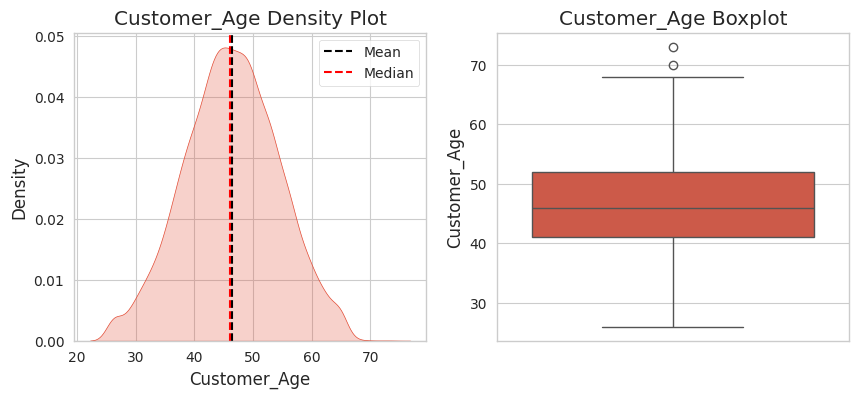

```python
num_col_summary('Customer_Age')
```

```
5-Point summary of Dependent_count

+-------+-------+------+------+------+-------+
|       |   Min |   Q1 |   Q2 |   Q3 |   Max |
|-------+-------+------+------+------+-------|
| Value |     0 |    1 |    2 |    3 |     5 |
+-------+-------+------+------+------+-------+
```

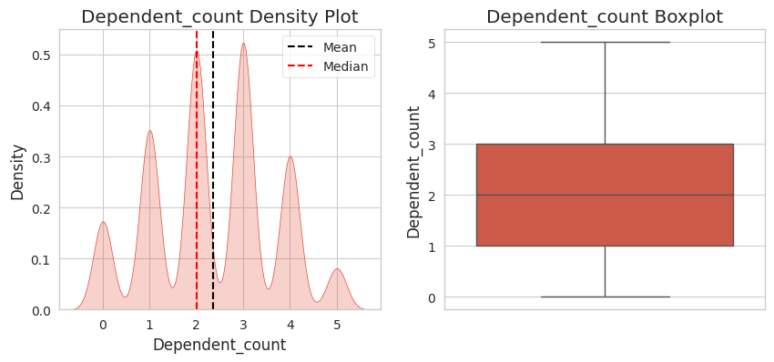

```python
num_col_summary( 'Dependent_count')
```

```
5-Point summary of Months_on_book

+-------+-------+------+------+------+-------+
|       |   Min |   Q1 |   Q2 |   Q3 |   Max |
|-------+-------+------+------+------+-------|
| Value |    13 |   31 |   36 |   40 |    56 |
+-------+-------+------+------+------+-------+
```

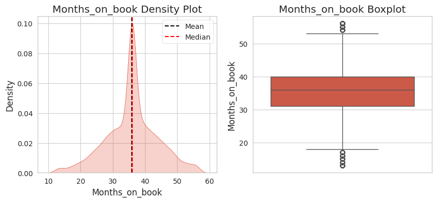

```python
num_col_summary( 'Months_on_book')
```

```
5-Point summary of Total_Relationship_Count

+-------+-------+------+------+------+-------+
|       |   Min |   Q1 |   Q2 |   Q3 |   Max |
|-------+-------+------+------+------+-------|
| Value |     1 |    3 |    4 |    5 |     6 |
+-------+-------+------+------+------+-------+
```

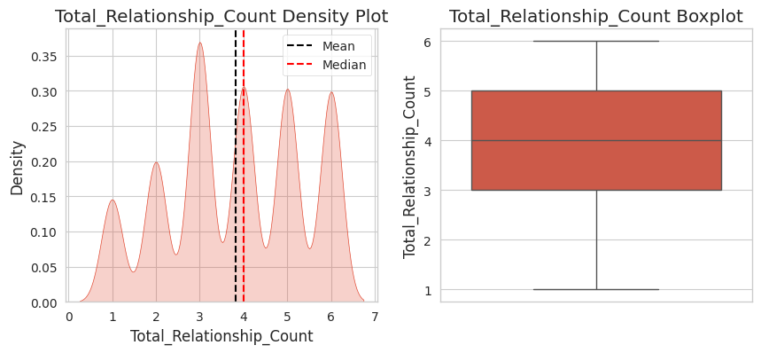

```python
num_col_summary( 'Total_Relationship_Count')
```

```
5-Point summary of Months_Inactive_12_mon

+-------+-------+------+------+------+-------+
|       |   Min |   Q1 |   Q2 |   Q3 |   Max |
|-------+-------+------+------+------+-------|
| Value |     0 |    2 |    2 |    3 |     6 |
+-------+-------+------+------+------+-------+
```

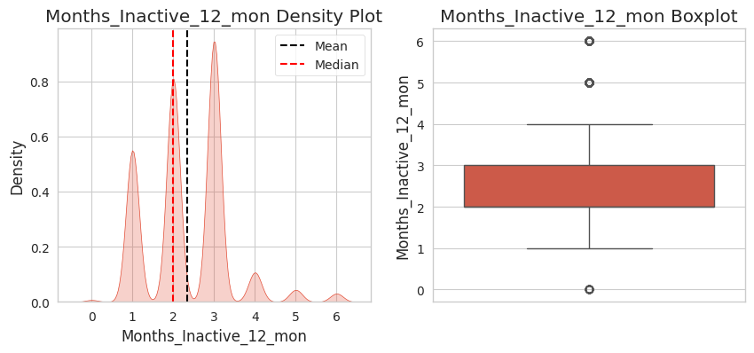

```python
num_col_summary( 'Months_Inactive_12_mon')
```

```
5-Point summary of Contacts_Count_12_mon

+-------+-------+------+------+------+-------+
|       |   Min |   Q1 |   Q2 |   Q3 |   Max |
|-------+-------+------+------+------+-------|
| Value |     0 |    2 |    2 |    3 |     6 |
+-------+-------+------+------+------+-------+
```

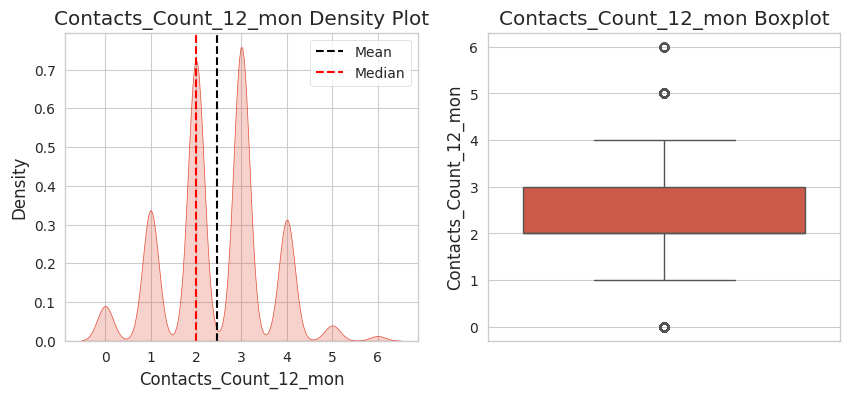

```python
num_col_summary( 'Contacts_Count_12_mon')
```

```
5-Point summary of Credit_Limit

+-------+--------+------+------+---------+-------+
|       |    Min |   Q1 |   Q2 |      Q3 |   Max |
|-------+--------+------+------+---------+-------|
| Value | 1438.3 | 2555 | 4549 | 11067.5 | 34516 |
+-------+--------+------+------+---------+-------+
```

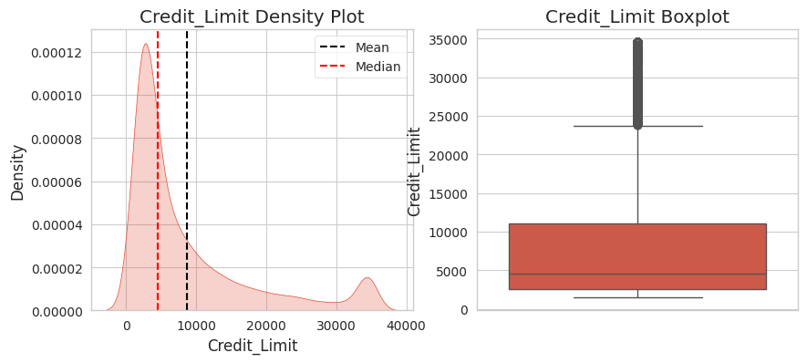

```python
num_col_summary('Credit_Limit')
```

```
5-Point summary of Total_Revolving_Bal

+-------+-------+------+------+------+-------+
|       |   Min |   Q1 |   Q2 |   Q3 |   Max |
|-------+-------+------+------+------+-------|
| Value |     0 |  359 | 1276 | 1784 |  2517 |
+-------+-------+------+------+------+-------+
```

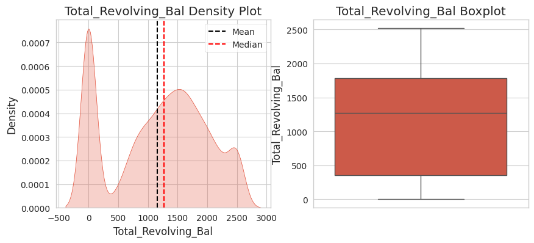

```python
num_col_summary ('Total_Revolving_Bal')
```

```
5-Point summary of Avg_Open_To_Buy

+-------+-------+--------+------+------+-------+
|       |   Min |     Q1 |   Q2 |   Q3 |   Max |
|-------+-------+--------+------+------+-------|
| Value |     3 | 1324.5 | 3474 | 9859 | 34516 |
+-------+-------+--------+------+------+-------+
```

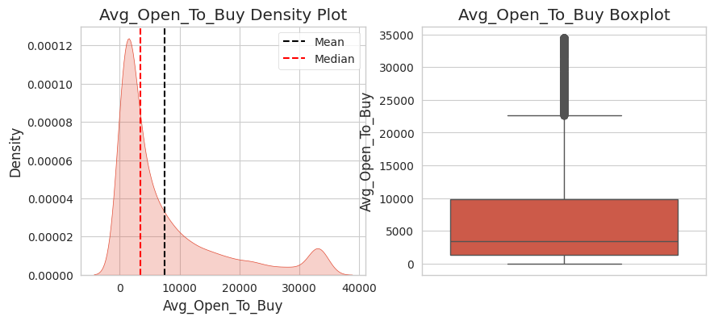

```python
num_col_summary('Avg_Open_To_Buy')
```

```
5-Point summary of Total_Amt_Chng_Q4_Q1

+-------+-------+-------+-------+-------+-------+
|       |   Min |    Q1 |    Q2 |    Q3 |   Max |
|-------+-------+-------+-------+-------+-------|
| Value |     0 | 0.631 | 0.736 | 0.859 | 3.397 |
+-------+-------+-------+-------+-------+-------+
```

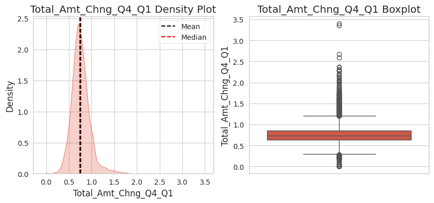

```python
num_col_summary( 'Total_Amt_Chng_Q4_Q1')
```

```
5-Point summary of Total_Trans_Amt

+-------+-------+--------+------+------+-------+
|       |   Min |     Q1 |   Q2 |   Q3 |   Max |
|-------+-------+--------+------+------+-------|
| Value |   510 | 2155.5 | 3899 | 4741 | 18484 |
+-------+-------+--------+------+------+-------+
```

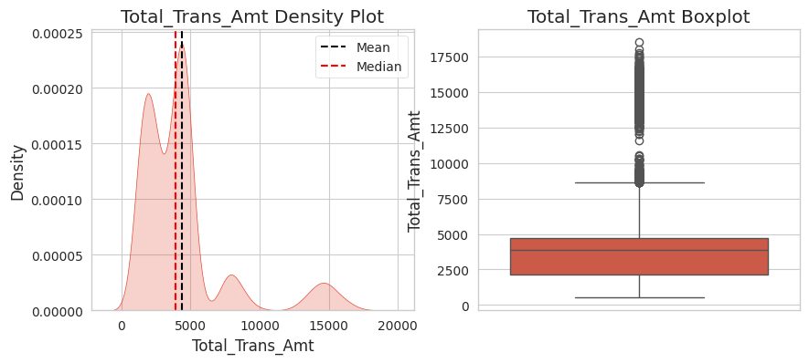

```python
num_col_summary( 'Total_Trans_Amt')
```

```
5-Point summary of Total_Trans_Ct

+-------+-------+------+------+------+-------+
|       |   Min |   Q1 |   Q2 |   Q3 |   Max |
|-------+-------+------+------+------+-------|
| Value |    10 |   45 |   67 |   81 |   139 |
+-------+-------+------+------+------+-------+
```

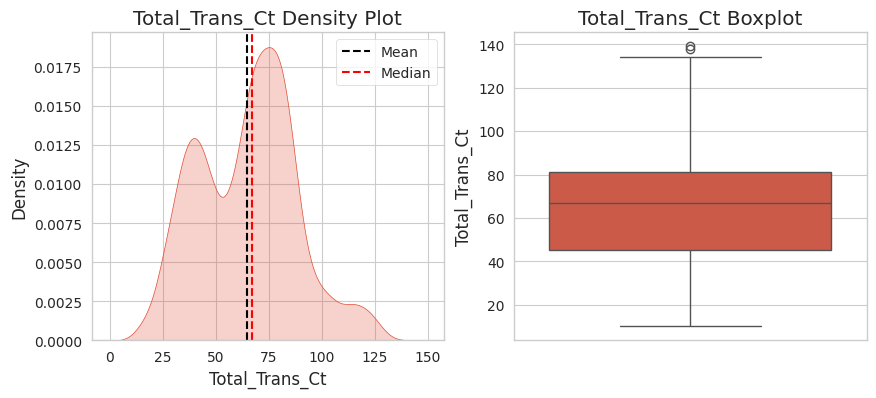

```python
num_col_summary( 'Total_Trans_Ct')
```

```
5-Point summary of Total_Ct_Chng_Q4_Q1

+-------+-------+-------+-------+-------+-------+
|       |   Min |    Q1 |    Q2 |    Q3 |   Max |
|-------+-------+-------+-------+-------+-------|
| Value |     0 | 0.582 | 0.702 | 0.818 | 3.714 |
+-------+-------+-------+-------+-------+-------+
```

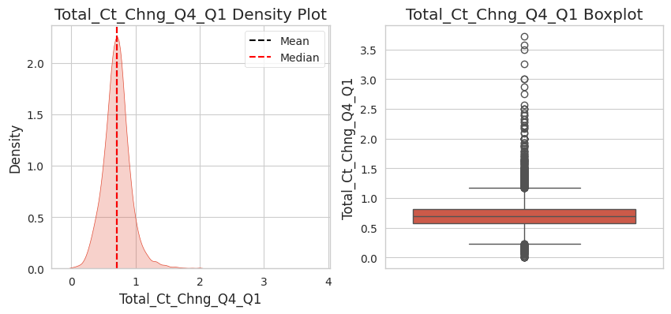

```python
num_col_summary('Total_Ct_Chng_Q4_Q1')
```

```
5-Point summary of Avg_Utilization_Ratio

+-------+-------+-------+-------+-------+-------+
|       |   Min |    Q1 |    Q2 |    Q3 |   Max |
|-------+-------+-------+-------+-------+-------|
| Value |     0 | 0.023 | 0.176 | 0.503 | 0.999 |
+-------+-------+-------+-------+-------+-------+
```

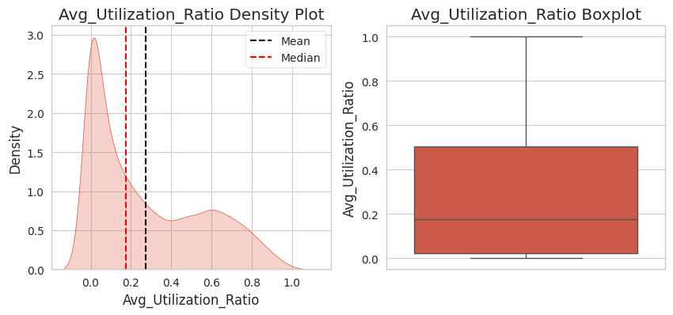

```python
num_col_summary('Avg_Utilization_Ratio')
```

## Univariate Analysis of Categorical Variables

```python
# Function to annotate percentage on countplot
def without_hue(ax, feature):
    total = len(feature)
    for p in ax.patches:
        percentage = '{:.1f}%'.format(100 * p.get_height() / total)
        x = p.get_x() + p.get_width() / 20.05
        y = p.get_y() + p.get_height()
        ax.annotate(percentage, (x, y), size=12)
    plt.xticks(rotation=45)

# Function to plot and annotate the countplot for categorical columns
def cat_summary(col):
    plt.figure(figsize=(8, 6))
    ax = sns.countplot(x=col, data=df1)
    without_hue(ax, df1[col])
    plt.title(f'Distribution of {col}')
    plt.show()
```

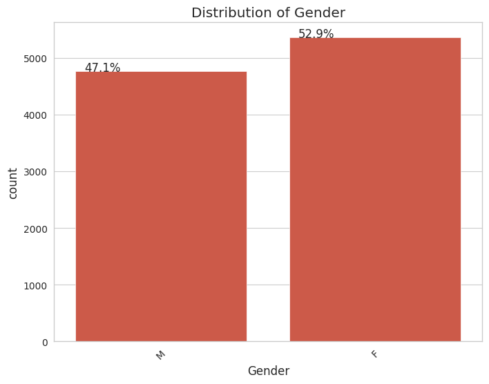

```python
cat_summary('Gender')
```

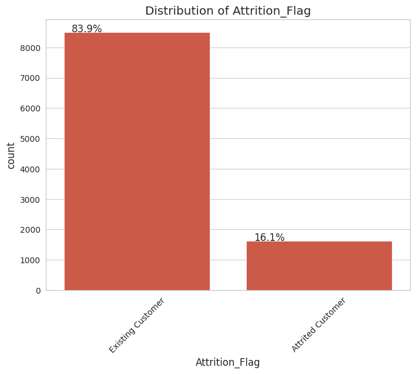

```python
 cat_summary('Attrition_Flag')
```

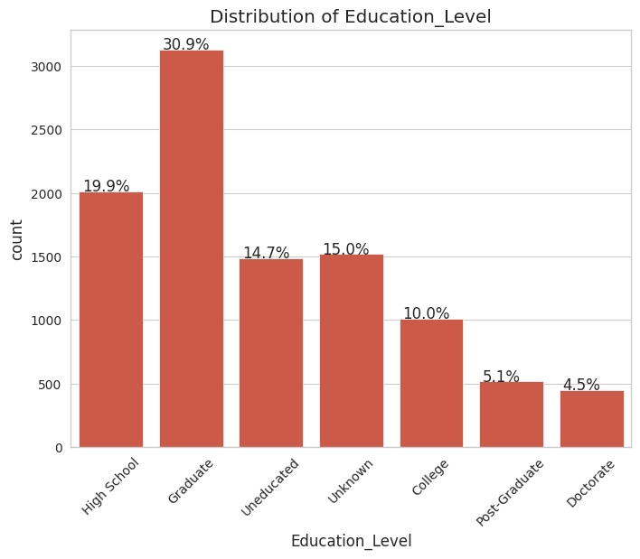

```python
cat_summary('Education_Level')
```

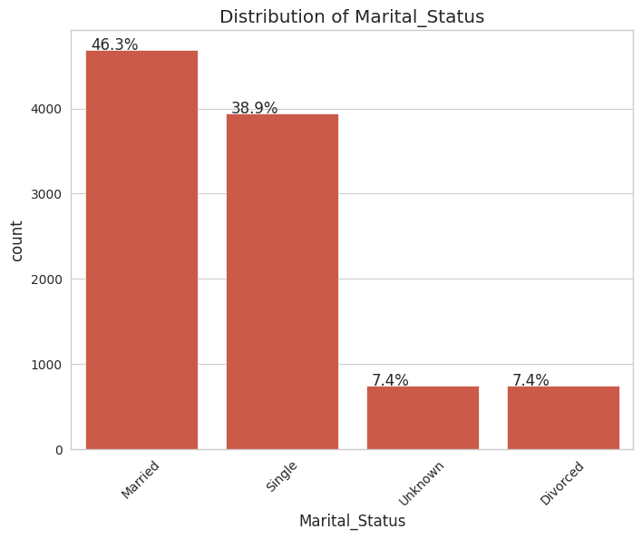

```python
cat_summary( 'Marital_Status')
```

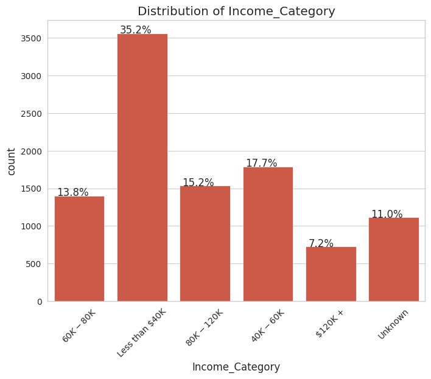

```python
cat_summary('Income_Category')
```

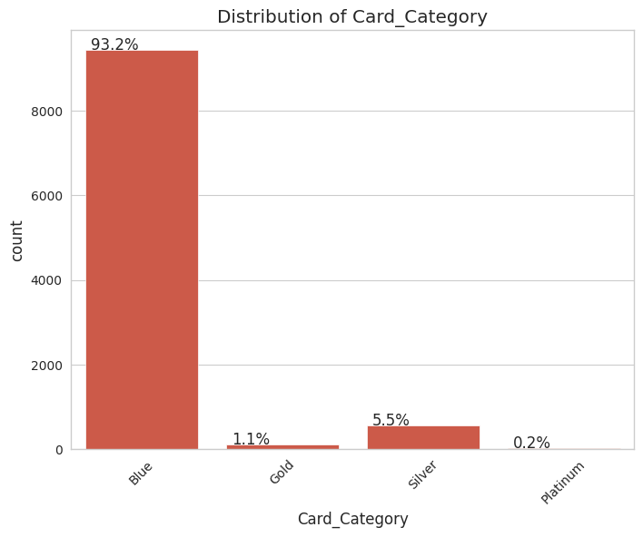

```python
cat_summary('Card_Category')
```

## Bivariate Analysis

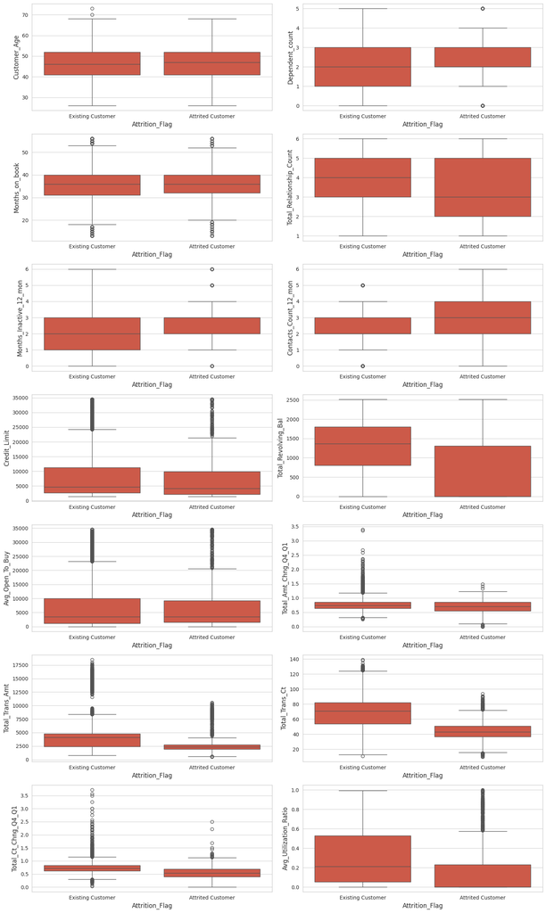

```python
# Creating subplots for numerical columns
fig, axes = plt.subplots(int(len(num_col) / 2), 2, figsize=(15, 25), dpi=100)

# Looping through each numerical column and creating boxplots
for idx, col in enumerate(num_col):
    row, col1 = idx // 2, idx % 2  # Calculate row and column position for subplots
    sns.boxplot(x='Attrition_Flag', y=col, data=df1, ax=axes[row, col1])

plt.tight_layout()  # Adjust the layout to prevent overlap
plt.show()  # Display the plot
```

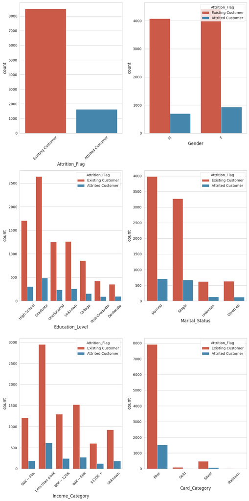

```python
# Make a copy of the categorical columns list
cat_col_n = cat_col.copy()

# Create subplots for categorical columns
fig, axes = plt.subplots(3, 2, figsize=(10, 20), dpi=100)

# Loop through each categorical column and create a countplot
for idx, col in enumerate(cat_col_n):
    row, col1 = idx // 2, idx % 2  # Calculate row and column positions for subplots
    sns.countplot(x=col, hue='Attrition_Flag', data=df1, ax=axes[row, col1])
    axes[row, col1].set_xticklabels(axes[row, col1].get_xticklabels(), rotation=45)  # Rotate x labels for readability

# Adjust the layout to prevent overlap
plt.tight_layout()
plt.show()
```

## Feature Engineering

```python
# Treating the "Unknown" values in the categorical columns by changing them to null (NaN)
for col in cat_col:
    df1[col] = df1[col].apply(lambda x: np.nan if x == 'Unknown' else x)
```

```python
# Checking the percentage of null values in each column
(df1.isnull().sum() / df1.shape[0]) * 100
```

|  | 0 |
| --- | --- |
| Attrition_Flag | 0.000000 |
| Customer_Age | 0.000000 |
| Gender | 0.000000 |
| Dependent_count | 0.000000 |
| Education_Level | 14.999506 |
| Marital_Status | 7.396070 |
| Income_Category | 10.980547 |
| Card_Category | 0.000000 |
| Months_on_book | 0.000000 |
| Total_Relationship_Count | 0.000000 |
| Months_Inactive_12_mon | 0.000000 |
| Contacts_Count_12_mon | 0.000000 |
| Credit_Limit | 0.000000 |
| Total_Revolving_Bal | 0.000000 |
| Avg_Open_To_Buy | 0.000000 |
| Total_Amt_Chng_Q4_Q1 | 0.000000 |
| Total_Trans_Amt | 0.000000 |
| Total_Trans_Ct | 0.000000 |
| Total_Ct_Chng_Q4_Q1 | 0.000000 |
| Avg_Utilization_Ratio | 0.000000 |

**dtype:** float64

```python
# Treating the missinkg values in the categorical columns
df1[ 'Marital_Status'] = df1['Marital_Status'].fillna (method = 'ffill')
```

```python
# Treating the missing values in the Education_Level column using forward fill
df1['Education_Level'] = df1['Education_Level'].fillna(method='ffill')
```

```python
# Treating the missing values in the 'Income_Category' column using forward fill
df1['Income_Category'] = df1['Income_Category'].fillna(method='ffill')

# Verify if the missing values are filled
print(df1['Income_Category'].unique())
```

```
['$60K - $80K' 'Less than $40K' '$80K - $120K' '$40K - $60K' '$120K +']
```

```python
  df1.isnull().sum()
```

|  | 0 |
| --- | --- |
| Attrition_Flag | 0 |
| Customer_Age | 0 |
| Gender | 0 |
| Dependent_count | 0 |
| Education_Level | 0 |
| Marital_Status | 0 |
| Income_Category | 0 |
| Card_Category | 0 |
| Months_on_book | 0 |
| Total_Relationship_Count | 0 |
| Months_Inactive_12_mon | 0 |
| Contacts_Count_12_mon | 0 |
| Credit_Limit | 0 |
| Total_Revolving_Bal | 0 |
| Avg_Open_To_Buy | 0 |
| Total_Amt_Chng_Q4_Q1 | 0 |
| Total_Trans_Amt | 0 |
| Total_Trans_Ct | 0 |
| Total_Ct_Chng_Q4_Q1 | 0 |
| Avg_Utilization_Ratio | 0 |

**dtype:** int64

## Encoding the data in the categorical Features

```python
# Encoding the target feature 'Attrition_Flag' in the dataset
df1['Attrition_Flag'] = df1['Attrition_Flag'].apply(lambda x: 1 if x == 'Attrited Customer' else 0)
```

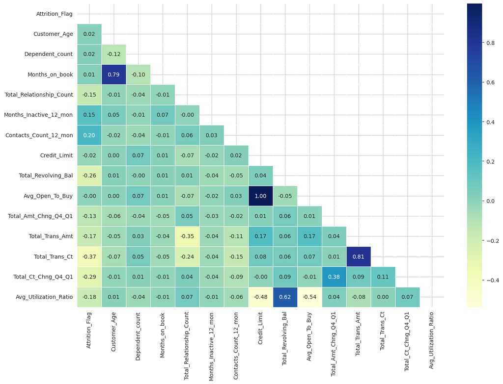

```python
# Select only numeric columns for correlation
numeric_df = df1.select_dtypes(include=[np.number])

# Checking the correlation of numeric features with the target variable
plt.figure(figsize=(15, 10))

# Create a mask for the upper triangle of the heatmap
mask = np.zeros_like(numeric_df.corr(), dtype=bool)
mask[np.triu_indices_from(mask)] = True

# Plotting the heatmap
sns.heatmap(numeric_df.corr(), linewidths=0.5, annot=True, fmt='.2f', cmap='YlGnBu', mask=mask)

plt.show()
```

1. From the above graph we can see that Avg_Open_To_Buy and credit limit are perfectly correlated
2. Avg_Open_To_Buy is not correlated to Attrition Flag. Thus we will drop this column.
3. we can observe from the above heatmap that there is no strong correlation between the independent features with our Target Feature, that is, Attrition_Flag

```python
# Select only numeric columns for correlation calculation
numeric_df = df1.select_dtypes(include=[np.number])

# Calculate the correlation matrix
correlation_matrix = numeric_df.corr()

# Get columns with correlation < 0.1 with respect to 'Attrition_Flag'
low_corr_cols = correlation_matrix[abs(correlation_matrix['Attrition_Flag']) < 0.1].index.tolist()

# Drop those columns
df1 = df1.drop(low_corr_cols, axis=1)

# Print the columns removed
print(f"Columns removed due to low correlation with Attrition_Flag: {low_corr_cols}")
```

```
Columns removed due to low correlation with Attrition_Flag: ['Customer_Age', 'Dependent_count', 'Months_on_book', 'Credit_Limit', 'Avg_Open_To_Buy']
```

```python
df1.select_dtypes (include = 'object').columns
```

```
Index(['Gender', 'Education_Level', 'Marital_Status', 'Income_Category',
       'Card_Category'],
      dtype='object')
```

We will encode the categorical features in two ways:

- Label encoding: If the categories in the feature being encoded is ordinal in nature
- One Hot Encoding: If the categories in the feature may or may not be ordinal

```python
# encoding the gender feature
df1['Gender'] = df1['Gender'].apply(lambda x: 1 if x== 'M' else 0)
```

```python
# checking the encoded 'Gender' feature in the data set
df1['Gender'].unique()
```

```
array([1, 0])
```

```python
# Label Encoding the ordinal categorical features: 'Education_Level'
df1['Education_Level'] = df1['Education_Level'].replace({'High School' :1, 'Graduate' :3, 'Uneducated': 0, 'College': 2, 'Post-Graduate': 4, 'Doctorate':5})
```

```python
# Label Encoding of Categories in Income_Category
df1['Income_Category'] = df1['Income_Category'].replace({
    '$60K - $80K': 2,
    'Less than $40K': 0,
    '$80K - $120K': 3,
    '$40K - $60K': 1,
    '$120K +': 4
})
```

```python
# Check if there are any remaining non-numeric values in 'Income_Category'
print(df1['Income_Category'].unique())
```

```
[2 0 3 1 4]
```

```python
# One-hot encoding for 'Marital Status' and 'Card_Category' columns
df2 = pd.get_dummies(data=df1, columns=['Marital_Status', 'Card_Category'], drop_first=True)
df2.head()
```

|  | Attrition_Flag | Gender | Education_Level | Income_Category | Total_Relationship_Count | Months_Inactive_12_mon | Contacts_Count_12_mon | Total_Revolving_Bal | Total_Amt_Chng_Q4_Q1 | Total_Trans_Amt | Total_Trans_Ct | Total_Ct_Chng_Q4_Q1 | Avg_Utilization_Ratio | Marital_Status_Married | Marital_Status_Single | Card_Category_Gold | Card_Category_Platinum | Card_Category_Silver |
| --- | --- | --- | --- | --- | --- | --- | --- | --- | --- | --- | --- | --- | --- | --- | --- | --- | --- | --- |
| 0 | 0 | 1 | 1 | 2 | 5 | 1 | 3 | 777 | 1.335 | 1144 | 42 | 1.625 | 0.061 | True | False | False | False | False |
| 1 | 0 | 0 | 3 | 0 | 6 | 1 | 2 | 864 | 1.541 | 1291 | 33 | 3.714 | 0.105 | False | True | False | False | False |
| 2 | 0 | 1 | 3 | 3 | 4 | 1 | 0 | 0 | 2.594 | 1887 | 20 | 2.333 | 0.000 | True | False | False | False | False |
| 3 | 0 | 0 | 1 | 0 | 3 | 4 | 1 | 2517 | 1.405 | 1171 | 20 | 2.333 | 0.760 | True | False | False | False | False |
| 4 | 0 | 1 | 0 | 2 | 5 | 1 | 0 | 0 | 2.175 | 816 | 28 | 2.500 | 0.000 | True | False | False | False | False |

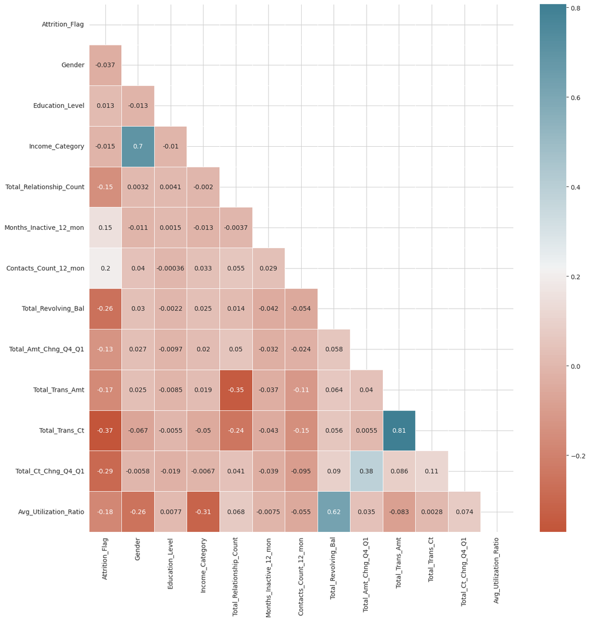

```python
# checking the correlation of different features in the data set to each other
# Set plot style
sns.set_style('whitegrid')

# Select only numeric columns from the DataFrame (df2)
numeric_df = df2.select_dtypes(include=[np.number])

# Calculate the correlation matrix for the numeric columns
corr = numeric_df.corr()

# Create a mask for the upper triangle of the heatmap
mask = np.zeros_like(corr, dtype=bool)
mask[np.triu_indices_from(mask)] = True

# Plotting the heatmap
plt.figure(figsize=(15, 15))
sns.heatmap(corr, annot=True, linewidths=0.5, cmap=sns.diverging_palette(20, 220, n=200), mask=mask)

plt.show()
```

```python
corr['Attrition_Flag']
```

|  | Attrition_Flag |
| --- | --- |
| Attrition_Flag | 1.000000 |
| Gender | -0.037272 |
| Education_Level | 0.013450 |
| Income_Category | -0.014545 |
| Total_Relationship_Count | -0.150005 |
| Months_Inactive_12_mon | 0.152449 |
| Contacts_Count_12_mon | 0.204491 |
| Total_Revolving_Bal | -0.263053 |
| Total_Amt_Chng_Q4_Q1 | -0.131063 |
| Total_Trans_Amt | -0.168598 |
| Total_Trans_Ct | -0.371403 |
| Total_Ct_Chng_Q4_Q1 | -0.290054 |
| Avg_Utilization_Ratio | -0.178410 |

**dtype:** float64

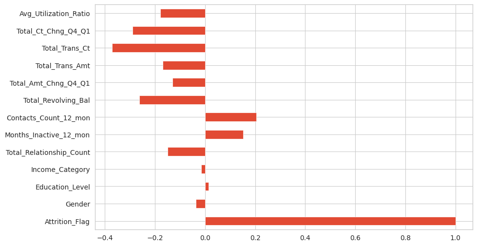

```python
corr['Attrition_Flag'].plot.barh(figsize = (10,6))
```

```python
# defining independent and target variables
Y = df2['Attrition_Flag']
X = df2.drop('Attrition_Flag', axis=1)
```

```python
# Splitting the data set into temporary and test dataset
x_temp,x_test,y_temp,y_test = train_test_split(X,Y, test_size = 0.20, random_state = 42, stratify = Y)
#Splitting the temp data set into train and validation data set
x_train,x_val,y_train, y_val = train_test_split(x_temp, y_temp, test_size = 0.3, random_state = 42, stratify = y_temp)
```

```python
# Checking the shape of each dataset and class distribution for each (train, validation, test)
pd.DataFrame({
    'Rows': [x_train.shape[0], x_val.shape[0], x_test.shape[0]],
    'Columns': [x_train.shape[1], x_val.shape[1], x_test.shape[1]],
    'Y(0)_ratio': [y_train.value_counts(normalize=True)[0],
                   y_val.value_counts(normalize=True)[0],
                   y_test.value_counts(normalize=True)[0]],
    'Y(1)_ratio': [y_train.value_counts(normalize=True)[1],
                   y_val.value_counts(normalize=True)[1],
                   y_test.value_counts(normalize=True)[1]]
}, index=['Train', 'Validation', 'Test'])
```

|  | Rows | Columns | Y(0)_ratio | Y(1)_ratio |
| --- | --- | --- | --- | --- |
| Train | 5670 | 17 | 0.839330 | 0.160670 |
| Validation | 2431 | 17 | 0.839161 | 0.160839 |
| Test | 2026 | 17 | 0.839585 | 0.160415 |

```python
# scaling the values of all the independent columns using Robust Scaler
num_col_2 = [
    "Total_Relationship_Count",
    "Months_Inactive_12_mon",
    "Contacts_Count_12_mon",
    "Total_Revolving_Bal",
    "Total_Amt_Chng_Q4_Q1",
    "Total_Trans_Amt",
    "Total_Trans_Ct",
    "Total_Ct_Chng_Q4_Q1",
    "Avg_Utilization_Ratio"
]

# Initialize RobustScaler
rc = RobustScaler(with_centering=False, with_scaling=True)

# Scaling the values for each dataset
x_train[num_col_2] = pd.DataFrame(rc.fit_transform(x_train[num_col_2]), columns=num_col_2, index=x_train.index)
x_val[num_col_2] = pd.DataFrame(rc.transform(x_val[num_col_2]), columns=num_col_2, index=x_val.index)
x_test[num_col_2] = pd.DataFrame(rc.transform(x_test[num_col_2]), columns=num_col_2, index=x_test.index)
```

```python
from sklearn.metrics import accuracy_score, precision_score, recall_score, f1_score, roc_auc_score
from sklearn.model_selection import StratifiedKFold, cross_val_score
from sklearn.linear_model import LogisticRegression
from sklearn.tree import DecisionTreeClassifier
from sklearn.ensemble import RandomForestClassifier
import lightgbm as lgb
import numpy as np
import pandas as pd

# Creating a function to calculate the different performance metrics on train, validation, and test data sets
def get_metrics(model, train_x, test_x, train_y, test_y, threshold=0.5, flag=False, roc=True):
    metrics_list = []

    # Predictions for train and test data
    train_pred = model.predict_proba(train_x)[:, 1] > threshold
    test_pred = model.predict_proba(test_x)[:, 1] > threshold

    # Rounding the predictions to binary
    train_pred = np.round(train_pred)
    test_pred = np.round(test_pred)

    # Accuracy
    train_acc = accuracy_score(train_y, train_pred)
    test_acc = accuracy_score(test_y, test_pred)

    # Precision
    train_prec = precision_score(train_y, train_pred)
    test_prec = precision_score(test_y, test_pred)

    # Recall
    train_recall = recall_score(train_y, train_pred)
    test_recall = recall_score(test_y, test_pred)

    # F1 Score
    train_f1 = f1_score(train_y, train_pred)
    test_f1 = f1_score(test_y, test_pred)

    # ROC AUC Score
    train_pred_prob = model.predict_proba(train_x)[:, 1]
    test_pred_prob = model.predict_proba(test_x)[:, 1]

    train_roc_auc_score = roc_auc_score(train_y, train_pred_prob)
    test_roc_auc_score = roc_auc_score(test_y, test_pred_prob)

    # Append all metrics to the list
    metrics_list.extend([train_acc, test_acc, train_prec, test_prec, train_recall, test_recall,
                         train_f1, test_f1, train_roc_auc_score, test_roc_auc_score])

    return metrics_list

# Defining a Dictionary to store the data related to model and different metric values
d1 = {
    'Model_Name': [],
    'Train_Acc': [],
    'Test_Acc': [],
    'Train_Prec': [],
    'Test_Prec': [],
    'Train_Recall': [],
    'Test_Recall': [],
    'Train_F1': [],
    'Test_F1': [],
    'Train_roc_auc': [],
    'Test_roc_auc': [],
    'Train_cv_score': []
}

# Creating a function to add the metric values to the dictionary for comparison of different models
def add_metric_score(model, score, cv_score):
    d1['Model_Name'].append(model)
    d1['Train_Acc'].append(score[0])
    d1['Test_Acc'].append(score[1])
    d1['Train_Prec'].append(score[2])
    d1['Test_Prec'].append(score[3])
    d1['Train_Recall'].append(score[4])
    d1['Test_Recall'].append(score[5])
    d1['Train_F1'].append(score[6])
    d1['Test_F1'].append(score[7])
    d1['Train_roc_auc'].append(score[8])
    d1['Test_roc_auc'].append(score[9])
    d1['Train_cv_score'].append(cv_score)

# Fitting different Machine Learning models and storing resultant metric scores for each model
models = []
cv_results = []

models.append(('Logistic Regression', LogisticRegression(random_state=42)))
models.append(('Decision Tree', DecisionTreeClassifier(random_state=42)))
models.append(('Random Forest', RandomForestClassifier(random_state=42)))
models.append(('Light GBM', lgb.LGBMClassifier(random_state=42, verbose=-1)))  # Set verbose=-1 to suppress logs

for name, model in models:
    Kfold = StratifiedKFold(n_splits=5, random_state=42, shuffle=True)
    metrics = 'recall'

    # Cross-validation
    cv_scores = cross_val_score(model, X=x_train, y=y_train, cv=Kfold, scoring=metrics)
    cv_results.append(cv_scores)

    # Fit the model on the training data
    model.fit(x_train, y_train)

    # Get metrics and add to dictionary
    metrics_list = get_metrics(model, train_x=x_train, test_x=x_val, train_y=y_train, test_y=y_val)
    add_metric_score(name, metrics_list, cv_scores.mean())

# Create a DataFrame to display the results
pd.DataFrame(d1).sort_values(by=['Train_cv_score', 'Test_Recall'], ascending=False) \
    .style.highlight_max(color='lightblue', axis=0) \
    .highlight_min(color='pink', axis=0)
```

|  | Model_Name | Train_Acc | Test_Acc | Train_Prec | Test_Prec | Train_Recall | Test_Recall | Train_F1 | Test_F1 | Train_roc_auc | Test_roc_auc | Train_cv_score |
| --- | --- | --- | --- | --- | --- | --- | --- | --- | --- | --- | --- | --- |
| 3 | Light GBM | 0.999647 | 0.964624 | 0.997809 | 0.917808 | 1.000000 | 0.856777 | 0.998904 | 0.886243 | 0.999999 | 0.990861 | 0.871537 |
| 1 | Decision Tree | 1.000000 | 0.924722 | 1.000000 | 0.765306 | 1.000000 | 0.767263 | 1.000000 | 0.766284 | 1.000000 | 0.861083 | 0.809007 |
| 2 | Random Forest | 1.000000 | 0.954751 | 1.000000 | 0.912023 | 1.000000 | 0.795396 | 1.000000 | 0.849727 | 1.000000 | 0.987164 | 0.800234 |
| 0 | Logistic Regression | 0.905115 | 0.901275 | 0.765292 | 0.763066 | 0.590560 | 0.560102 | 0.666667 | 0.646018 | 0.925586 | 0.924814 | 0.585096 |

#### **Inference:**

From the above results, we can observe that the **Train_cv_score** and **Test recall** are highest when using the **Light GBM Classifier** algorithm. Thus, we will now perform tuning of the **Light GBM model** and check the **feature importances** of different features contributing towards predicting our target feature.

While exploring the data earlier, we observed that the data is unevenly distributed if we consider the target feature in the dataset. This imbalanced distribution of the target variable can impact the model's performance, particularly in terms of recall. To address this issue, we will explore techniques like **upsampling** and **downsampling** to balance the dataset and improve model prediction accuracy.

```python
from imblearn.over_sampling import SMOTE

# Checking the shape of the dataset before upsampling
print("Number of rows in the data set = {}".format(x_train.shape[0]))
print("Number of columns in the data set = {}\n".format(x_train.shape[1]))

# Applying SMOTE for upsampling the minority class
smt = SMOTE(sampling_strategy='minority', random_state=42, k_neighbors=15)
x_train_up, y_train_up = smt.fit_resample(x_train, y_train)

# Checking the shape of the dataset after resampling
print("Number of rows in the oversampled data set = {}".format(x_train_up.shape[0]))
print("Number of columns in the oversampled data set = {}".format(x_train_up.shape[1]))

# Checking the count of y labels before and after resampling
print("Count of label before resampling:\n")
print(y_train.value_counts())

print("Count of label after resampling: \n")
print(y_train_up.value_counts())
```

```
Number of rows in the data set = 5670
Number of columns in the data set = 17

Number of rows in the oversampled data set = 9518
Number of columns in the oversampled data set = 17
Count of label before resampling:

Attrition_Flag
0    4759
1     911
Name: count, dtype: int64
Count of label after resampling:

Attrition_Flag
0    4759
1    4759
Name: count, dtype: int64
```

```python
# List of models for upsampled data
models_up_sampled = []
models_up_sampled.append(('Logistic Regression (upsampled)', LogisticRegression(random_state=42)))
models_up_sampled.append(('Decision Tree (Upsampled)', DecisionTreeClassifier(random_state=42)))
models_up_sampled.append(('Random Forest (Upsampled)', RandomForestClassifier(random_state=42)))
models_up_sampled.append(('Light GBM (Upsampled)', lgb.LGBMClassifier(random_state=42)))

# Loop to fit models and store metrics
for name, model in models_up_sampled:
    metrics = 'recall'  # We will use recall as the evaluation metric

    # Stratified K-fold cross-validation
    kfold = StratifiedKFold(n_splits=5, shuffle=True, random_state=42)

    # Cross-validation results
    cv_results_up = cross_val_score(model, x_train_up, y_train_up, scoring=metrics, cv=kfold, n_jobs=4)

    # Append the cross-validation results to the list
    cv_results.append(cv_results_up)

    # Fit the model on the upsampled training data
    model.fit(x_train_up, y_train_up)

    # Get metrics for the upsampled model
    metrics_list = get_metrics(model, x_train_up, x_val, y_train_up, y_val)

    # Add the metric score to the dictionary for comparison
    add_metric_score(name, metrics_list, cv_results_up.mean())

# Create a DataFrame to display the results, sorted by 'Train_cv_score' and 'Test_Recall'
pd.DataFrame(d1).sort_values(by=['Train_cv_score', 'Test_Recall'], ascending=False) \
    .style.highlight_max(color='lightblue', axis=0) \
    .highlight_min(color='pink', axis=0)
```

|  | Model_Name | Train_Acc | Test_Acc | Train_Prec | Test_Prec | Train_Recall | Test_Recall | Train_F1 | Test_F1 | Train_roc_auc | Test_roc_auc | Train_cv_score |
| --- | --- | --- | --- | --- | --- | --- | --- | --- | --- | --- | --- | --- |
| 7 | Light GBM (Upsampled) | 0.998949 | 0.964624 | 0.998112 | 0.880299 | 0.999790 | 0.902813 | 0.998950 | 0.891414 | 0.999997 | 0.989192 | 0.980038 |
| 6 | Random Forest (Upsampled) | 1.000000 | 0.954751 | 1.000000 | 0.841849 | 1.000000 | 0.884910 | 1.000000 | 0.862843 | 1.000000 | 0.985813 | 0.979828 |
| 5 | Decision Tree (Upsampled) | 1.000000 | 0.918963 | 1.000000 | 0.707265 | 1.000000 | 0.846547 | 1.000000 | 0.770664 | 1.000000 | 0.889695 | 0.946418 |
| 4 | Logistic Regression (upsampled) | 0.878861 | 0.849856 | 0.872675 | 0.521523 | 0.887161 | 0.805627 | 0.879858 | 0.633166 | 0.945259 | 0.921429 | 0.886322 |
| 3 | Light GBM | 0.999647 | 0.964624 | 0.997809 | 0.917808 | 1.000000 | 0.856777 | 0.998904 | 0.886243 | 0.999999 | 0.990861 | 0.871537 |
| 1 | Decision Tree | 1.000000 | 0.924722 | 1.000000 | 0.765306 | 1.000000 | 0.767263 | 1.000000 | 0.766284 | 1.000000 | 0.861083 | 0.809007 |
| 2 | Random Forest | 1.000000 | 0.954751 | 1.000000 | 0.912023 | 1.000000 | 0.795396 | 1.000000 | 0.849727 | 1.000000 | 0.987164 | 0.800234 |
| 0 | Logistic Regression | 0.905115 | 0.901275 | 0.765292 | 0.763066 | 0.590560 | 0.560102 | 0.666667 | 0.646018 | 0.925586 | 0.924814 | 0.585096 |

```python
# Downsampling the training data using RandomUnderSampler
rus = RandomUnderSampler(sampling_strategy='majority', random_state=42)
x_train_down, y_train_down = rus.fit_resample(x_train, y_train)

# List of models for downsampled data
models_down = []
models_down.append(('Logistic Regression (Down-sampled)', LogisticRegression(random_state=42)))
models_down.append(('Decision Tree (Down-Sampled)', DecisionTreeClassifier(random_state=42)))
models_down.append(('Random Forest (Down-Sampled)', RandomForestClassifier(random_state=42)))
models_down.append(('Light GBM (Down-Sampled)', lgb.LGBMClassifier(random_state=42)))

# Loop to fit models and store metrics for the downsampled data
cv_results = []
for name, model in models_down:
    metrics = 'recall'  # Using recall as the evaluation metric

    # Stratified K-fold cross-validation
    kfold = StratifiedKFold(n_splits=5, shuffle=True, random_state=42)

    # Cross-validation results
    cv_score = cross_val_score(model, x_train_down, y_train_down, scoring=metrics, n_jobs=4, cv=kfold)
    cv_results.append(cv_score)

    # Fit the model on the downsampled training data
    model.fit(x_train_down, y_train_down)

    # Get metrics for the downsampled model
    metrics_list = get_metrics(model, x_train_down, x_val, y_train_down, y_val)

    # Add the metric score to the dictionary for comparison
    add_metric_score(name, metrics_list, cv_score.mean())

# Create a DataFrame to display the results, sorted by 'Train_cv_score' and 'Test_Recall'
pd.DataFrame(d1).sort_values(by=['Train_cv_score', 'Test_Recall'], ascending=False) \
    .style.highlight_max(color='lightblue', axis=0) \
    .highlight_min(color='pink', axis=0)
```

|  | Model_Name | Train_Acc | Test_Acc | Train_Prec | Test_Prec | Train_Recall | Test_Recall | Train_F1 | Test_F1 | Train_roc_auc | Test_roc_auc | Train_cv_score |
| --- | --- | --- | --- | --- | --- | --- | --- | --- | --- | --- | --- | --- |
| 7 | Light GBM (Upsampled) | 0.998949 | 0.964624 | 0.998112 | 0.880299 | 0.999790 | 0.902813 | 0.998950 | 0.891414 | 0.999997 | 0.989192 | 0.980038 |
| 6 | Random Forest (Upsampled) | 1.000000 | 0.954751 | 1.000000 | 0.841849 | 1.000000 | 0.884910 | 1.000000 | 0.862843 | 1.000000 | 0.985813 | 0.979828 |
| 11 | Light GBM (Down-Sampled) | 1.000000 | 0.944467 | 1.000000 | 0.764463 | 1.000000 | 0.946292 | 1.000000 | 0.845714 | 1.000000 | 0.987508 | 0.953906 |
| 15 | Light GBM (Down-Sampled) | 1.000000 | 0.944467 | 1.000000 | 0.764463 | 1.000000 | 0.946292 | 1.000000 | 0.845714 | 1.000000 | 0.987508 | 0.953906 |
| 10 | Random Forest (Down-Sampled) | 1.000000 | 0.930481 | 1.000000 | 0.710227 | 1.000000 | 0.959079 | 1.000000 | 0.816104 | 1.000000 | 0.981959 | 0.949505 |
| 14 | Random Forest (Down-Sampled) | 1.000000 | 0.930481 | 1.000000 | 0.710227 | 1.000000 | 0.959079 | 1.000000 | 0.816104 | 1.000000 | 0.981959 | 0.949505 |
| 5 | Decision Tree (Upsampled) | 1.000000 | 0.918963 | 1.000000 | 0.707265 | 1.000000 | 0.846547 | 1.000000 | 0.770664 | 1.000000 | 0.889695 | 0.946418 |
| 4 | Logistic Regression (upsampled) | 0.878861 | 0.849856 | 0.872675 | 0.521523 | 0.887161 | 0.805627 | 0.879858 | 0.633166 | 0.945259 | 0.921429 | 0.886322 |
| 9 | Decision Tree (Down-Sampled) | 1.000000 | 0.884821 | 1.000000 | 0.593909 | 1.000000 | 0.897698 | 1.000000 | 0.714868 | 1.000000 | 0.890026 | 0.875944 |
| 13 | Decision Tree (Down-Sampled) | 1.000000 | 0.884821 | 1.000000 | 0.593909 | 1.000000 | 0.897698 | 1.000000 | 0.714868 | 1.000000 | 0.890026 | 0.875944 |
| 3 | Light GBM | 0.999647 | 0.964624 | 0.997809 | 0.917808 | 1.000000 | 0.856777 | 0.998904 | 0.886243 | 0.999999 | 0.990861 | 0.871537 |
| 8 | Logistic Regression (Down-sampled) | 0.853458 | 0.832579 | 0.853070 | 0.488095 | 0.854007 | 0.838875 | 0.853538 | 0.617121 | 0.925454 | 0.921739 | 0.846376 |
| 12 | Logistic Regression (Down-sampled) | 0.853458 | 0.832579 | 0.853070 | 0.488095 | 0.854007 | 0.838875 | 0.853538 | 0.617121 | 0.925454 | 0.921739 | 0.846376 |
| 1 | Decision Tree | 1.000000 | 0.924722 | 1.000000 | 0.765306 | 1.000000 | 0.767263 | 1.000000 | 0.766284 | 1.000000 | 0.861083 | 0.809007 |
| 2 | Random Forest | 1.000000 | 0.954751 | 1.000000 | 0.912023 | 1.000000 | 0.795396 | 1.000000 | 0.849727 | 1.000000 | 0.987164 | 0.800234 |
| 0 | Logistic Regression | 0.905115 | 0.901275 | 0.765292 | 0.763066 | 0.590560 | 0.560102 | 0.666667 | 0.646018 | 0.925586 | 0.924814 | 0.585096 |

```python
from sklearn.ensemble import RandomForestClassifier
from sklearn.model_selection import RandomizedSearchCV
from scipy.stats import randint as sp_randint

# Define a smaller parameter grid for RandomizedSearchCV to speed up the process
params = {
    'n_estimators': sp_randint(100, 150),  # Reduced range
    'max_depth': sp_randint(5, 15),         # Reduced range
    'min_samples_split': sp_randint(10, 30),  # Reduced range
    'min_samples_leaf': sp_randint(10, 30),  # Reduced range
    'max_features': sp_randint(1, 15)       # Reduced range
}

# Initialize the Random Forest Classifier
rfc = RandomForestClassifier(random_state=10)

# Set up the RandomizedSearchCV with fewer iterations and folds
rsearch = RandomizedSearchCV(estimator=rfc, param_distributions=params, scoring='recall',
                             n_iter=50, cv=3, n_jobs=-1, return_train_score=True)  # Reduced n_iter and cv

# Fit the model with the downsampled training data
rsearch.fit(x_train_down, y_train_down)
```

```
RandomizedSearchCV(cv=3, estimator=RandomForestClassifier(random_state=10),
                   n_iter=50, n_jobs=-1,
                   param_distributions={'max_depth': <scipy.stats._distn_infrastructure.rv_discrete_frozen object at 0x7c26d6793c10>,
                                        'max_features': <scipy.stats._distn_infrastructure.rv_discrete_frozen object at 0x7c26d9ffd350>,
                                        'min_samples_leaf': <scipy.stats._distn_infrastructure.rv_discrete_frozen object at 0x7c26d9ffdd90>,
                                        'min_samples_split': <scipy.stats._distn_infrastructure.rv_discrete_frozen object at 0x7c26d9fff450>,
                                        'n_estimators': <scipy.stats._distn_infrastructure.rv_discrete_frozen object at 0x7c26d9f7cf90>},
                   return_train_score=True, scoring='recall')
```

```python
best_params = rsearch.best_params_
```

```python
from sklearn.metrics import confusion_matrix, accuracy_score, roc_auc_score, classification_report, cohen_kappa_score
from sklearn.ensemble import RandomForestClassifier

# Define the model evaluation function
def model_res(algo, x_train=x_train_down, x_test=x_test, y_train=y_train_down, y_test=y_test):
    # Fit the model
    algo.fit(x_train, y_train)

    # Predictions
    y_train_pred = algo.predict(x_train)
    y_test_pred = algo.predict(x_test)

    # ROC AUC Score
    roc_score = roc_auc_score(y_test, algo.predict_proba(x_test)[:, 1])

    # Confusion matrix and classification report for training data
    print('Confusion Matrix for Train Data:')
    print(confusion_matrix(y_train, y_train_pred))
    print('Accuracy Score (Train) = {}'.format(accuracy_score(y_train, y_train_pred)))
    print('ROC AUC Score (Train) = {}'.format(roc_score))

    # Confusion matrix and classification report for test data
    print('Confusion Matrix for Test Data:')
    print(confusion_matrix(y_test, y_test_pred))
    print('Accuracy Score (Test) = {}'.format(accuracy_score(y_test, y_test_pred)))
    print('ROC AUC Score (Test) = {}'.format(roc_score))

    # Print classification report (only for test data)
    print('Classification Report (Test Data):')
    print(classification_report(y_test, y_test_pred))

    # Cohen Kappa Score
    print('Cohen Kappa Score = {}'.format(cohen_kappa_score(y_test, y_test_pred)))

# Assuming `best_params` contains the best hyperparameters from RandomizedSearchCV
rfc_tuned = RandomForestClassifier(**best_params, random_state=42)

# Call model_res with the tuned RandomForestClassifier
model_res(rfc_tuned)
```

```
Confusion Matrix for Train Data:
[[856  55]
 [ 30 881]]
Accuracy Score (Train) = 0.9533479692645445
ROC AUC Score (Train) = 0.9735232668566002
Confusion Matrix for Test Data:
[[1557  144]
 [  30  295]]
Accuracy Score (Test) = 0.914116485686081
ROC AUC Score (Test) = 0.9735232668566002
Classification Report (Test Data):
              precision    recall  f1-score   support

           0       0.98      0.92      0.95      1701
           1       0.67      0.91      0.77       325

    accuracy                           0.91      2026
   macro avg       0.83      0.91      0.86      2026
weighted avg       0.93      0.91      0.92      2026

Cohen Kappa Score = 0.7207761656504403
```

```python
from sklearn.model_selection import RandomizedSearchCV
import lightgbm as lgb
import numpy as np

# Define the hyperparameters for RandomizedSearchCV
params_lgb = {
    'min_gain_to_split': [0.01, 0.1, 0.2, 0.3],
    'min_data_in_leaf': range(5, 50, 10),
    'feature_fraction': [0.5, 0.9, 1.0],
    'max_depth': range(5, 50, 5),
    'extra_trees': [True, False],
    'learning_rate': np.linspace(0.01, 0.2, 10),
    'boosting_type': ['gbdt'],
    'objective': ['binary'],
    'is_unbalance': [True],
    'metric': ['binary_logloss']
}

# Initialize the LGBMClassifier
lgbmc = lgb.LGBMClassifier(random_state=42)

# Set up the RandomizedSearchCV for hyperparameter tuning using the defined parameter grid
rsearch_lgb = RandomizedSearchCV(estimator=lgbmc, param_distributions=params_lgb,
                                 scoring='recall', n_iter=50, n_jobs=-1, cv=3, return_train_score=True)

# Fit the model using the downsampled training data
rsearch_lgb.fit(x_train_down, y_train_down)
```

```
RandomizedSearchCV(cv=3, estimator=LGBMClassifier(random_state=42), n_iter=50,
                   n_jobs=-1,
                   param_distributions={'boosting_type': ['gbdt'],
                                        'extra_trees': [True, False],
                                        'feature_fraction': [0.5, 0.9, 1.0],
                                        'is_unbalance': [True],
                                        'learning_rate': array([0.01      , 0.03111111, 0.05222222, 0.07333333, 0.09444444,
       0.11555556, 0.13666667, 0.15777778, 0.17888889, 0.2       ]),
                                        'max_depth': range(5, 50, 5),
                                        'metric': ['binary_logloss'],
                                        'min_data_in_leaf': range(5, 50, 10),
                                        'min_gain_to_split': [0.01, 0.1, 0.2,
                                                              0.3],
                                        'objective': ['binary']},
                   return_train_score=True, scoring='recall')
```

```python
best_params_lgb = rsearch_lgb.best_params_
best_params_lgb
```

```
{'objective': 'binary',
 'min_gain_to_split': 0.2,
 'min_data_in_leaf': 15,
 'metric': 'binary_logloss',
 'max_depth': 40,
 'learning_rate': 0.1577777777777778,
 'is_unbalance': True,
 'feature_fraction': 0.5,
 'extra_trees': False,
 'boosting_type': 'gbdt'}
```

```python
# Initialize the LightGBM model with the best parameters
lgbmc_tuned = lgb.LGBMClassifier(**best_params_lgb, random_state=10)

# Call the model_res function to evaluate the model
model_res(lgbmc_tuned)
```

```
Confusion Matrix for Train Data:
[[911   0]
 [  0 911]]
Accuracy Score (Train) = 1.0
ROC AUC Score (Train) = 0.9830326052548275
Confusion Matrix for Test Data:
[[1590  111]
 [  25  300]]
Accuracy Score (Test) = 0.932872655478776
ROC AUC Score (Test) = 0.9830326052548275
Classification Report (Test Data):
              precision    recall  f1-score   support

           0       0.98      0.93      0.96      1701
           1       0.73      0.92      0.82       325

    accuracy                           0.93      2026
   macro avg       0.86      0.93      0.89      2026
weighted avg       0.94      0.93      0.94      2026

Cohen Kappa Score = 0.7748863140591478
```

```python
# Get feature importances
f_imp = pd.DataFrame({'Features': x_train_down.columns, 'Importance': lgbmc_tuned.feature_importances_})

# Sort the features by importance
f_imp_sorted = f_imp.sort_values(by='Importance', ascending=False)

# Display the sorted feature importances
print(f_imp_sorted)
```

```
                    Features  Importance
8            Total_Trans_Amt         359
9             Total_Trans_Ct         269
7       Total_Amt_Chng_Q4_Q1         263
10       Total_Ct_Chng_Q4_Q1         257
6        Total_Revolving_Bal         172
11     Avg_Utilization_Ratio         113
3   Total_Relationship_Count          88
4     Months_Inactive_12_mon          63
5      Contacts_Count_12_mon          58
2            Income_Category          34
1            Education_Level          18
0                     Gender          16
12    Marital_Status_Married           7
13     Marital_Status_Single           0
14        Card_Category_Gold           0
15    Card_Category_Platinum           0
16      Card_Category_Silver           0
```

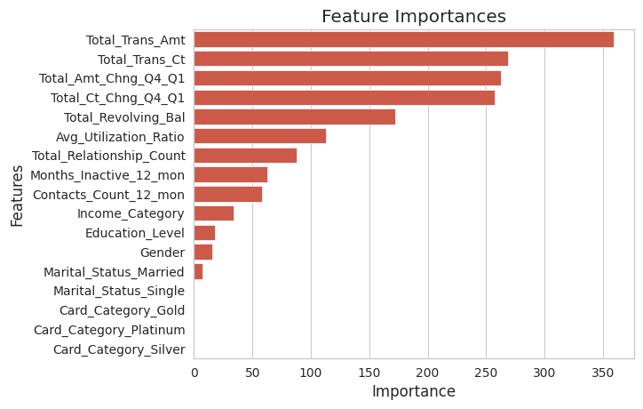

```python
# Create the bar plot for feature importances
sns.barplot(x='Importance', y='Features', data=f_imp.sort_values(by='Importance', ascending=False))

# Add title and labels
plt.title('Feature Importances')
plt.xlabel('Importance')
plt.ylabel('Features')

# Show the plot
plt.show()
```